# Statistical Methods

Polynomial Regression

Fall 2025 | Course PSYC 790  
Jeffrey M. Girard | Lecture 13a

# Overview

## Motivation

- So far, we have always fit straight lines between $y$ and $x$ variables
- But sometimes the correct functional form is curved in some way
- If we fit a straight line anyway, our results may be very biased

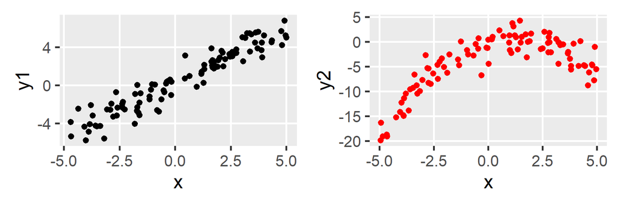

```r
set.seed(2023)
df1 <- tibble(
  x = runif(100, -5, 5),
  y1 = 0.2 + 1.2*x + rnorm(100, 0, 1)
)
df2 <- tibble(
  x = runif(100, -5, 5),
  y2 = 0.2 + 1.2*x - 0.5*x^2 + rnorm(100, 0, 2)
)

p1 <- ggplot(df1, aes(x, y1)) +
  geom_point(size = 2) +
  # geom_smooth(method = "lm", se = FALSE, color = "red", linewidth = 1.5,
  #             formula = y ~ x + I(x^2)) +
  # geom_smooth(method = "lm", se = FALSE, color = "blue", linewidth = 1.5,
  #             formula = y ~ x) +
  mytheme(20)
p2 <- ggplot(df2, aes(x, y2)) +
  geom_point(size = 2, color = "red") +
  # geom_smooth(method = "lm", se = FALSE, color = "red", linewidth = 1.5,
  #             formula = y ~ x + I(x^2)) +
  # geom_smooth(method = "lm", se = FALSE, color = "blue", linewidth = 1.5,
  #             formula = y ~ x) +
  mytheme(20)

(p1 | p2)
```

## Linear regression

```r
fit <- lm(y2 ~ x, data = df2) # data from right panel of slide 3

model_parameters(fit)
## Parameter   | Coefficient |   SE |         95% CI |  t(98) |      p
## -------------------------------------------------------------------
## (Intercept) |       -4.54 | 0.43 | [-5.39, -3.70] | -10.66 | < .001
## x           |        1.19 | 0.14 | [ 0.90,  1.47] |   8.29 | < .001

r2(fit)
## # R2 for Linear Regression
##        R2: 0.412
##   adj. R2: 0.406
```

## Visualizing the model

```r
library(ggeffects)
plot(predict_response(fit, terms = "x"), show_data = TRUE)
```

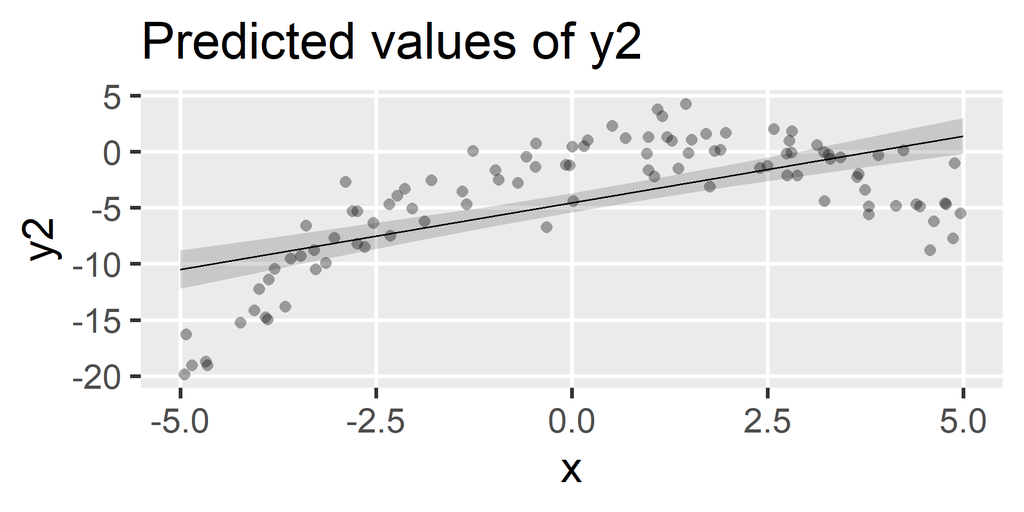

```r
library(ggeffects)
plot(predict_response(fit, terms = "x"), show_data = TRUE, dot_size = 3) + mytheme()
```

## Assumption checking

```r
check_model(fit, check = "linearity")
```

```r
see:::plot.see_check_model(check_model(fit, check = "linearity", panel = FALSE))$NCV +
  mytheme() +
  theme(
    plot.title.position = "plot",
    plot.title = element_text(hjust = 0, size = 22),
    plot.subtitle = element_text(hjust = 0, size = 20)
  )
```

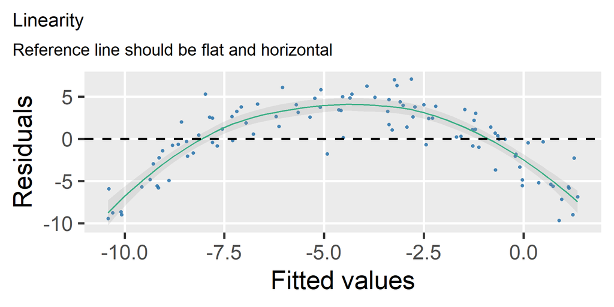

## Conclusions

- Linear regression did not work well for predicting $y_2$
- The functional form diagnostic looked bad for the latter
- The $R^2$ for the latter was worse than we could do
- We need to change our functional form!
- We need to allow a curve in our function
- This is what polynomial regression does

# Polynomial Regression

## Power polynomials

- LM can handle simple curves through **power polynomial** transformations!
- We will add predictors that are *power transformations* of other predictors

$$\hat{y} = b_0 + b_1 \color{red}{x^1} + b_2 \color{red}{x^2} + \cdots + b_d \color{red}{x^d}$$

- Each term has a **degree** equal to its exponent
  - e.g., $x^1$ is the *first* degree term and $x^2$ is the *second* degree term
  - Note that $x^1=x$ and $x^0=1$, which can be thought of as the intercept
  - The term with the highest exponent is the **highest degree term**
  - All other terms are referred to as the **lower degree terms**

## Number of bends

- The highest degree term determines the curve’s overall shape
  - The number of bends is equal to $(d-1)$

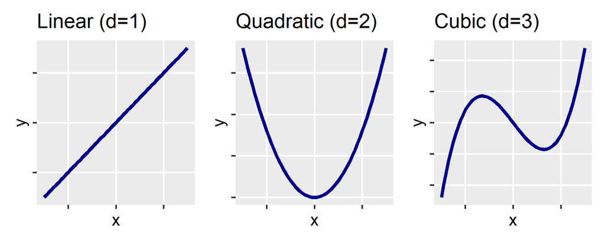

```r
d1 <- tibble(x = seq(-3, 3, .1), y = x^1) |>
  ggplot(aes(x, y)) +
  geom_line(linewidth = 2, color = "darkblue") +
  labs(title = "Linear (d=1)") +
  mytheme(20) +
  theme(axis.text = element_blank())
d2 <- tibble(x = seq(-3, 3, .1), y = x^2) |>
  ggplot(aes(x, y)) +
  geom_line(linewidth = 2, color = "darkblue") +
  labs(title = "Quadratic (d=2)") +
  mytheme(20) +
  theme(axis.text = element_blank())
d3 <- tibble(x = seq(-3, 3, .1), y = -5*x + x^3) |>
  ggplot(aes(x, y)) +
  geom_line(linewidth = 2, color = "darkblue") +
  labs(title = "Cubic (d=3)") +
  mytheme(20) +
  theme(axis.text = element_blank())

(d1 | d2 | d3)
```

## Direction of curvature

- The sign $(\pm)$ of the curve’s highest degree term’s slope  
  determines its **direction of curvature** (i.e., up or down)

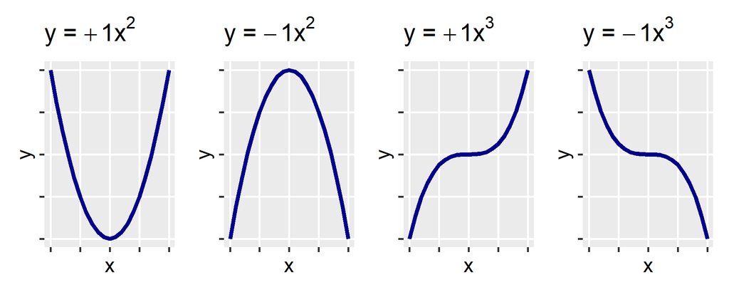

```r
qp <- tibble(x = seq(-10, 10, 1), y = x^2) |>
  ggplot(aes(x, y)) +
  geom_line(linewidth = 2, color = "darkblue") +
  labs(title = expression(paste("y = ", +1*x^2))) +
  mytheme(20) +
  theme(axis.text = element_blank())
qn <- tibble(x = seq(-10, 10, 1), y = -x^2) |>
  ggplot(aes(x, y)) +
  geom_line(linewidth = 2, color = "darkblue") +
  labs(title = expression(paste("y = ", -1*x^2))) +
  mytheme(20) +
  theme(axis.text = element_blank())
cp <- tibble(x = seq(-10, 10, 1), y = x^3) |>
  ggplot(aes(x, y)) +
  geom_line(linewidth = 2, color = "darkblue") +
  labs(title = expression(paste("y = ", +1*x^3))) +
  mytheme(20) +
  theme(axis.text = element_blank())
cn <- tibble(x = seq(-10, 10, 1), y = -x^3) |>
  ggplot(aes(x, y)) +
  geom_line(linewidth = 2, color = "darkblue") +
  labs(title = expression(paste("y = ", -1*x^3))) +
  mytheme(20) +
  theme(axis.text = element_blank())

(qp | qn | cp | cn)
```

# Quadratic Regression

## Expanding the equation

- A quadratic relationship requires two predictors to represent $x$

$$\hat{y} = b_0 + b_1 x^1 + b_2 x^2$$

- The **highest** degree coefficient determines the overall shape
  - $b_2$: Does the curve bend up $(+)$, down $(-)$, or not at all $(0)$?
- The **lower** degree coefficients fine-tune the position and shape
  - $b_1$: What is the slope of the curve’s tangent line at $x=0$?
  - $b_0$: What is the intercept of the curve’s tangent line at $x=0$?

## Quadratic regression 1

- We use the `I()` function to do math inside the formula

```r
fit1b <- lm(y1 ~ x + I(x^2), data = df1)

model_parameters(fit1b)
## Parameter   | Coefficient |   SE |        95% CI | t(97) |      p
## -----------------------------------------------------------------
## (Intercept) |        0.27 | 0.15 | [-0.02, 0.57] |  1.82 | 0.072
## x           |        1.13 | 0.04 | [ 1.05, 1.20] | 30.43 | < .001
## x^2         |    3.05e-03 | 0.01 | [-0.03, 0.03] |  0.21 | 0.838

r2(fit1b)
## # R2 for Linear Regression
##        R2: 0.908
##   adj. R2: 0.906
```

The $x^2$ slope is NOT significant, so the curve is NOT needed

## Visualizing the model

```r
plot(predict_response(fit1b, terms = "x"), show_data = TRUE)
```

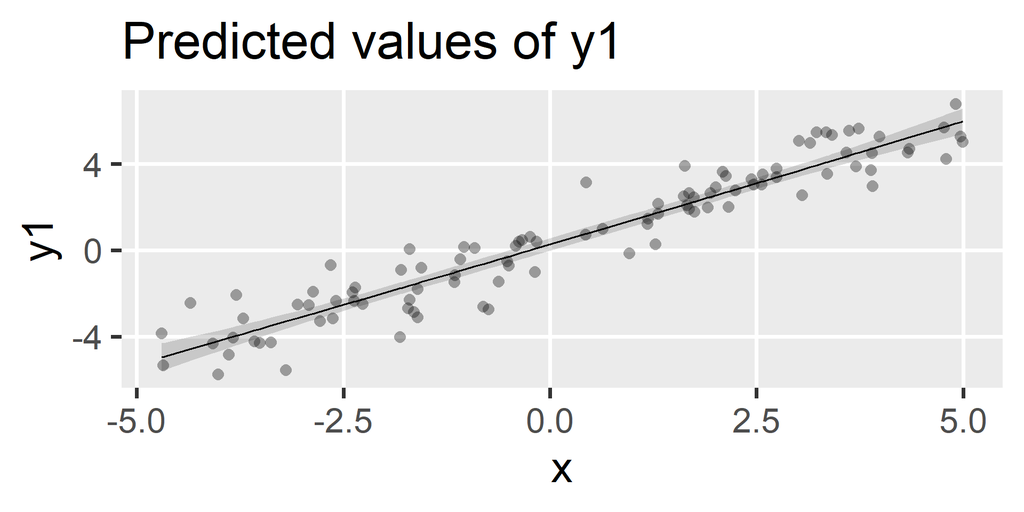

```r
plot(predict_response(fit1b, terms = "x"), show_data = TRUE, dot_size = 3) + mytheme()
```

## Assumption checking

```r
check_model(fit1b, check = "linearity")
```

```r
see:::plot.see_check_model(check_model(fit1b, check = "linearity", panel = FALSE))$NCV +
  mytheme() +
  theme(
    plot.title.position = "plot",
    plot.title = element_text(hjust = 0, size = 22),
    plot.subtitle = element_text(hjust = 0, size = 20)
  )
```

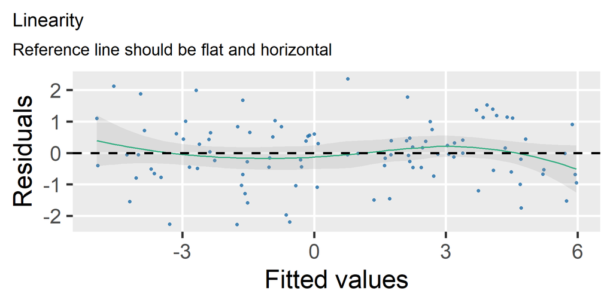

## Quadratic regression 2

```r
fit2b <- lm(y2 ~ x + I(x^2), data = df2)

model_parameters(fit2b)
## Parameter   | Coefficient |   SE |         95% CI |  t(97) |      p
## -------------------------------------------------------------------
## (Intercept) |       -0.16 | 0.31 | [-0.77,  0.45] |  -0.53 | 0.599
## x           |        1.27 | 0.07 | [ 1.13,  1.40] |  18.85 | < .001
## x^2         |       -0.50 | 0.03 | [-0.55, -0.44] | -18.71 | < .001

r2(fit2b)
## # R2 for Linear Regression
##        R2: 0.872
##   adj. R2: 0.870
```

- The $x^2$ slope is significant, so the curve is needed!
- Because the slope is negative, it will bend downward

## Visualizing the model

```r
plot(predict_response(fit2b, terms = "x"), show_data = TRUE)
```

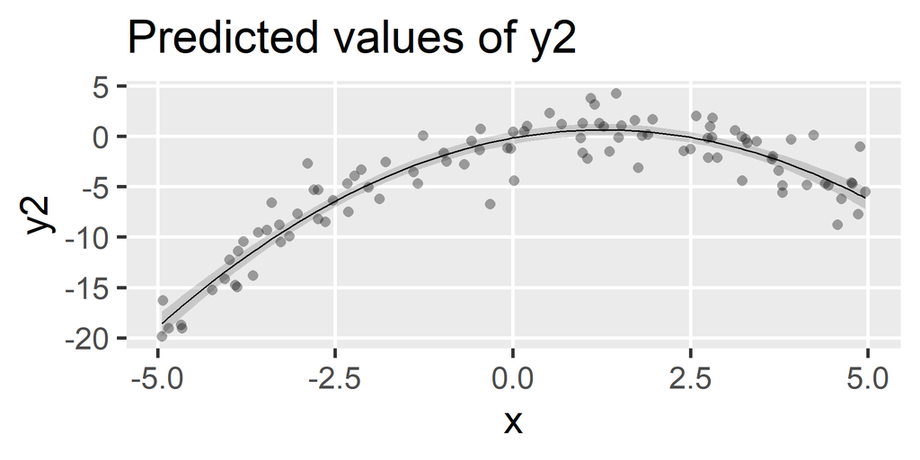

```r
plot(predict_response(fit2b, terms = "x"), show_data = TRUE, dot_size = 3) + mytheme()
```

## Assumption checking

```r
check_model(fit2b, check = "linearity")
```

```r
see:::plot.see_check_model(check_model(fit2b, check = "linearity", panel = FALSE))$NCV +
  mytheme() +
  theme(
    plot.title.position = "plot",
    plot.title = element_text(hjust = 0, size = 22),
    plot.subtitle = element_text(hjust = 0, size = 20)
  )
```

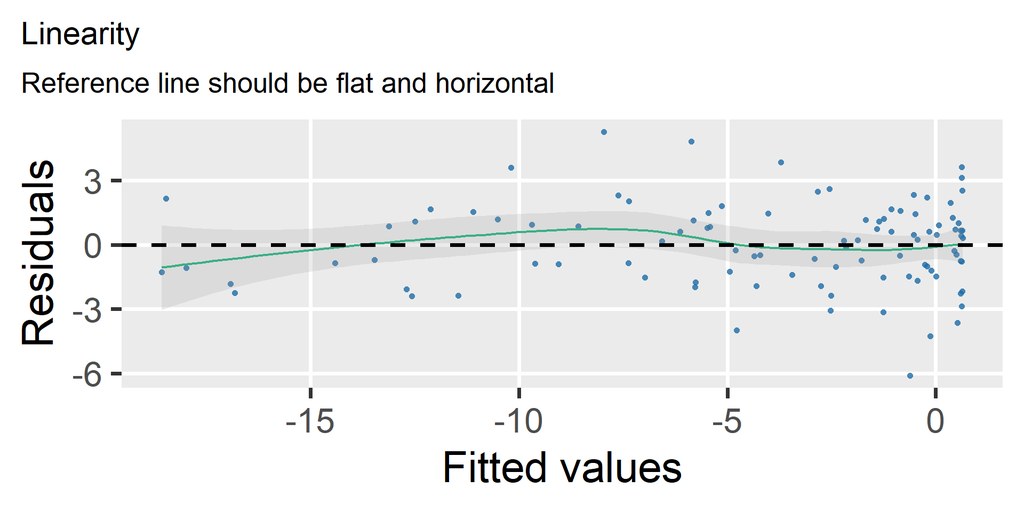

## Visualizing the tangent line

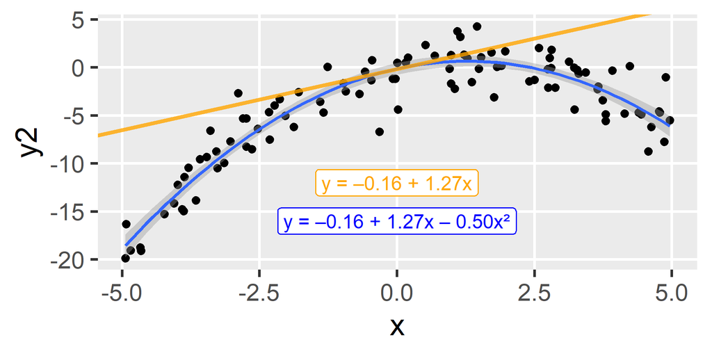

```r
ggplot(df2, aes(x = x, y = y2)) +
  geom_point(size = 2.5) +
  geom_smooth(method = "lm", formula = y ~ x + I(x^2), linewidth = 1.5) +
  geom_abline(
    slope = 1.27,
    intercept = -0.16,
    color = "orange",
    linewidth = 2,
    alpha = 4/5
  ) +
  annotate(
    geom = "label",
    x = 0,
    y = -12,
    label = "y = –0.16 + 1.27x",
    color = "orange",
    size = 7
  ) +
  annotate(
    geom = "label",
    x = 0,
    y = -16,
    label = "y = –0.16 + 1.27x – 0.50x²",
    color = "blue",
    size = 7
  ) +
  mytheme()
```

## Calculating extrema

- It may be useful to know the maximum or minimum values

What value of $x$ gives the  
most extreme value of $y$?

$$x_m = \frac{-b_1}{2b_2}$$

What is the most extreme value of $y$ in the function?

$$\hat{y}_m = \frac{4 b_2 b_0 - b_1^2}{4 b_2}$$

## Calculating extrema

```r
model_parameters(fit2b)
## Parameter   | Coefficient |   SE |         95% CI |  t(97) |      p
## -------------------------------------------------------------------
## (Intercept) |       -0.16 | 0.31 | [-0.77,  0.45] |  -0.53 | 0.599
## x           |        1.27 | 0.07 | [ 1.13,  1.40] |  18.85 | < .001
## x^2         |       -0.50 | 0.03 | [-0.55, -0.44] | -18.71 | < .001

b_0 <- -0.16
b_1 <-  1.27
b_2 <- -0.50

x_m <- (-b_1) / (2 * b_2)
x_m
## [1] 1.27

yhat_m <- ((4 * b_2 * b_0) - b_1^2) / (4 * b_2)
yhat_m
## [1] 0.64645
```

## Visualizing extrema

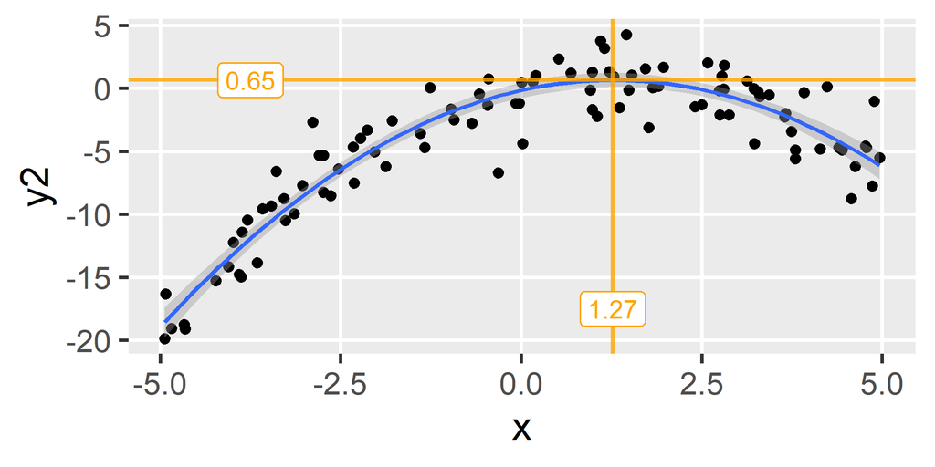

```r
ggplot(df2, aes(x = x, y = y2)) +
  geom_point(size = 2.5) +
  geom_smooth(method = "lm", formula = y ~ x + I(x^2), linewidth = 1.5) +
  geom_hline(yintercept = 0.64645, color = "orange", linewidth = 1.5, alpha = 4/5) +
  geom_vline(xintercept = 1.27, color = "orange", linewidth = 1.5, alpha = 4/5) +
  annotate("label", x = 1.27, y = -17.5, label = "1.27", size = 7, color = "orange") +
  annotate("label", x = -3.75, y = 0.64645, label = "0.65", size = 7, color = "orange") +
  mytheme()
```

# Adding Predictors

## Adding another predictor

```r
library(tidyverse)
salaries <- read_csv("salaries.csv")

fit3 <- lm(salary ~ yrs.since.phd + I(yrs.since.phd^2) + sex, data = salaries)

model_parameters(fit3)
## Parameter       | Coefficient |       SE |         95% CI | t(393) |      p
## ---------------------------------------------------------------------------
## (Intercept)     |       57.33 |     5.35 | [46.82, 67.85] |  10.72 | < .001
## yrs since phd   |        4.07 |     0.36 | [ 3.35,  4.78] |  11.20 | < .001
## yrs since phd^2 |       -0.06 | 7.22e-03 | [-0.08, -0.05] |  -8.90 | < .001
## sex [Male]      |        9.11 |     4.28 | [ 0.70, 17.53] |   2.13 | 0.034
```

- The effects of `yrs.since.phd` are significant controlling for sex
- The effect of `sex` is significant controlling for `yrs.since.phd` and its square

## Visualizing the model

```r
plot(predict_response(fit3, terms = c("yrs.since.phd", "sex")), show_data = TRUE)
```

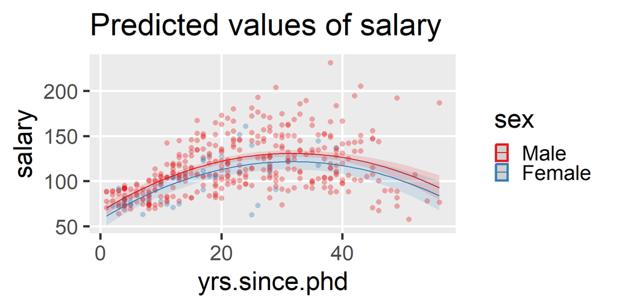

```r
plot(predict_response(fit3, terms = c("yrs.since.phd", "sex")), show_data = TRUE) + mytheme()
```

## Adding moderation

```r
fit4 <- lm(
  salary ~ yrs.since.phd + I(yrs.since.phd^2) + sex +
    yrs.since.phd:sex + I(yrs.since.phd^2):sex,
  data = salaries
)

model_parameters(fit4)
## Parameter                    | Coefficient |    SE |          95% CI | t(391) |      p
## --------------------------------------------------------------------------------------
## (Intercept)                  |       65.02 | 12.60 | [ 40.24, 89.80] |   5.16 | < .001
## yrs since phd                |        2.95 |  1.50 | [ -0.00,  5.90] |   1.96 | 0.050
## yrs since phd^2              |       -0.03 |  0.04 | [ -0.11,  0.04] |  -0.90 | 0.367
## sex [Male]                   |        0.91 | 13.29 | [-25.21, 27.03] |   0.07 | 0.946
## yrs since phd × sex [Male]   |        1.18 |  1.55 | [ -1.86,  4.22] |   0.76 | 0.447
## yrs since phd^2 × sex [Male] |       -0.03 |  0.04 | [ -0.11,  0.05] |  -0.79 | 0.432
```

- The effects of `yrs.since.phd` are not moderated by sex

## Visualizing the model

```r
plot(predict_response(fit4, terms = c("yrs.since.phd", "sex")))
```

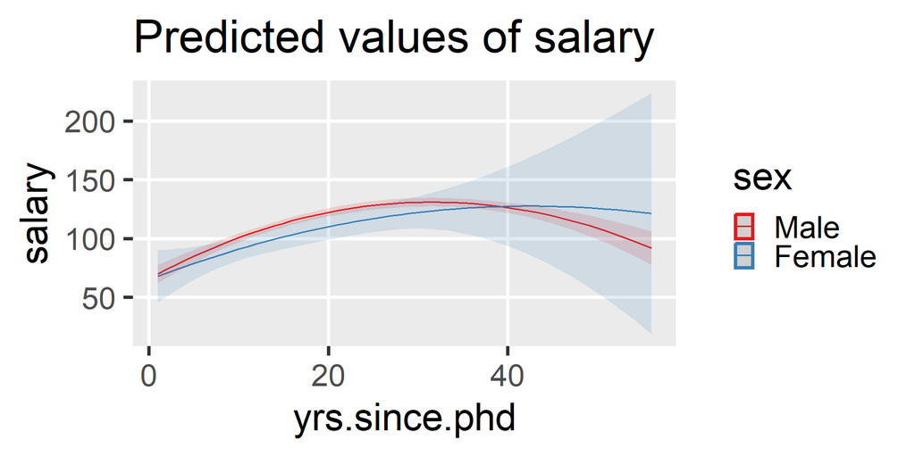

```r
plot(predict_response(fit4, terms = c("yrs.since.phd", "sex"))) + mytheme()
```

# Closing Thoughts

## Consider the range

- You may only see *part* of the curve in your sample!

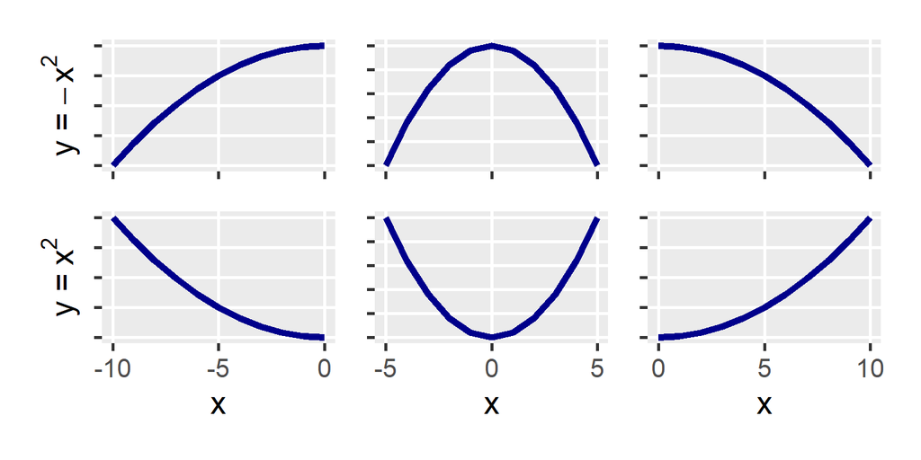

## Advice

- Models with higher degrees are more flexible
  - But they may overfit (fail to generalize)
  - They will be harder to interpret and justify
- **Theory** should be used to decide between shapes
  - Quadratics can model processes with best/worst regions
  - Cubics can model opponent processes and regulation
- Centering your $x$ variable is very helpful here
  - Also see `poly()` for orthogonal polynomials
- Don’t omit the lower degree terms/coefficients